# Final Project

Tsega Abebe

2025-04-08

```r
# Libraries
library(tidyverse)
library(skimr)
library(caret)
library(dplyr)
```

```r
#Load the dataset
cell2cell <- read.csv("cell2celltrain.csv", stringsAsFactors = TRUE)
head(cell2cell)
```

```
##   CustomerID Churn MonthlyRevenue MonthlyMinutes TotalRecurringCharge
## 1    3000002   Yes          24.00            219                   22
## 2    3000010   Yes          16.99             10                   17
## 3    3000014    No          38.00              8                   38
## 4    3000022    No          82.28           1312                   75
## 5    3000026   Yes          17.14              0                   17
## 6    3000030    No          38.05            682                   52
##   DirectorAssistedCalls OverageMinutes RoamingCalls PercChangeMinutes
## 1                  0.25              0            0              -157
## 2                  0.00              0            0                -4
## 3                  0.00              0            0                -2
## 4                  1.24              0            0               157
## 5                  0.00              0            0                 0
## 6                  0.25              0            0               148
##   PercChangeRevenues DroppedCalls BlockedCalls UnansweredCalls
```

[output cut: 76 more lines]

*Data Exploration*

```r
#Check the structure
str(cell2cell)
```

```
## 'data.frame':    51047 obs. of  58 variables:
##  $ CustomerID               : int  3000002 3000010 3000014 3000022 3000026 3000030 3000038 3000042 3000046 3000050 ...
##  $ Churn                    : Factor w/ 2 levels "No","Yes": 2 2 1 1 2 1 1 1 1 1 ...
##  $ MonthlyRevenue           : num  24 17 38 82.3 17.1 ...
##  $ MonthlyMinutes           : int  219 10 8 1312 0 682 26 98 24 1056 ...
##  $ TotalRecurringCharge     : int  22 17 38 75 17 52 30 66 35 75 ...
##  $ DirectorAssistedCalls    : num  0.25 0 0 1.24 0 0.25 0.25 2.48 0 0 ...
##  $ OverageMinutes           : int  0 0 0 0 0 0 0 0 0 0 ...
##  $ RoamingCalls             : num  0 0 0 0 0 0 0 0 0 0 ...
##  $ PercChangeMinutes        : int  -157 -4 -2 157 0 148 60 24 20 43 ...
##  $ PercChangeRevenues       : num  -19 0 0 8.1 -0.2 -3.1 4 6.8 -0.3 2.4 ...
##  $ DroppedCalls             : num  0.7 0.3 0 52 0 9 0 0 0 0 ...
##  $ BlockedCalls             : num  0.7 0 0 7.7 0 1.7 1 0.3 0 0 ...
##  $ UnansweredCalls          : num  6.3 2.7 0 76 0 13 2.3 4 1 0 ...
##  $ CustomerCareCalls        : num  0 0 0 4.3 0 0.7 0 4 0 0 ...
```

[output cut: 44 more lines]

We can see that the dataset has 51,047 rows and 58 columns. There are a mix of data types: - Numeric: 26 columns - Categorical: 23 columns - Integer: 9 columns

```r
# Check for missing values and summary statistics
skim(cell2cell)
```

Data summary

| Name | cell2cell |
| --- | --- |
| Number of rows | 51047 |
| Number of columns | 58 |
| _______________________ |  |
| Column type frequency: |  |
| factor | 23 |
| numeric | 35 |
| ________________________ |  |
| Group variables | None |

**Variable type: factor**

| skim_variable | n_missing | complete_rate | ordered | n_unique | top_counts |
| --- | --- | --- | --- | --- | --- |
| Churn | 0 | 1 | FALSE | 2 | No: 36336, Yes: 14711 |
| ServiceArea | 0 | 1 | FALSE | 748 | NYC: 1684, HOU: 1510, DAL: 1498, NYC: 1182 |
| ChildrenInHH | 0 | 1 | FALSE | 2 | No: 38679, Yes: 12368 |
| HandsetRefurbished | 0 | 1 | FALSE | 2 | No: 43956, Yes: 7091 |
| HandsetWebCapable | 0 | 1 | FALSE | 2 | Yes: 46046, No: 5001 |
| TruckOwner | 0 | 1 | FALSE | 2 | No: 41524, Yes: 9523 |
| RVOwner | 0 | 1 | FALSE | 2 | No: 46894, Yes: 4153 |
| Homeownership | 0 | 1 | FALSE | 2 | Kno: 33987, Unk: 17060 |
| BuysViaMailOrder | 0 | 1 | FALSE | 2 | No: 32596, Yes: 18451 |
| RespondsToMailOffers | 0 | 1 | FALSE | 2 | No: 31821, Yes: 19226 |
| OptOutMailings | 0 | 1 | FALSE | 2 | No: 50295, Yes: 752 |
| NonUSTravel | 0 | 1 | FALSE | 2 | No: 48168, Yes: 2879 |
| OwnsComputer | 0 | 1 | FALSE | 2 | No: 41583, Yes: 9464 |
| HasCreditCard | 0 | 1 | FALSE | 2 | Yes: 34503, No: 16544 |
| NewCellphoneUser | 0 | 1 | FALSE | 2 | No: 41223, Yes: 9824 |
| NotNewCellphoneUser | 0 | 1 | FALSE | 2 | No: 44012, Yes: 7035 |
| OwnsMotorcycle | 0 | 1 | FALSE | 2 | No: 50368, Yes: 679 |
| HandsetPrice | 0 | 1 | FALSE | 16 | Unk: 28982, 30: 7328, 150: 4115, 130: 2105 |
| MadeCallToRetentionTeam | 0 | 1 | FALSE | 2 | No: 49302, Yes: 1745 |
| CreditRating | 0 | 1 | FALSE | 7 | 2-H: 18993, 1-H: 8522, 3-G: 8410, 5-L: 6499 |
| PrizmCode | 0 | 1 | FALSE | 4 | Oth: 24655, Sub: 16378, Tow: 7589, Rur: 2425 |
| Occupation | 0 | 1 | FALSE | 8 | Oth: 37637, Pro: 8755, Cra: 1519, Cle: 986 |
| MaritalStatus | 0 | 1 | FALSE | 3 | Unk: 19700, Yes: 18651, No: 12696 |

**Variable type: numeric**

| skim_variable | n_missing | complete_rate | mean | sd | p0 | p25 | p50 | p75 | p100 | hist |
| --- | --- | --- | --- | --- | --- | --- | --- | --- | --- | --- |
| CustomerID | 0 | 1.00 | 3201956.88 | 116905.56 | 3000002.00 | 3100632.00 | 3201534.00 | 3305376.00 | 3399994.00 | ▇▇▇▇▇ |
| MonthlyRevenue | 156 | 1.00 | 58.83 | 44.51 | -6.17 | 33.61 | 48.46 | 71.06 | 1223.38 | ▇▁▁▁▁ |
| MonthlyMinutes | 156 | 1.00 | 525.65 | 529.87 | 0.00 | 158.00 | 366.00 | 723.00 | 7359.00 | ▇▁▁▁▁ |
| TotalRecurringCharge | 156 | 1.00 | 46.83 | 23.85 | -11.00 | 30.00 | 45.00 | 60.00 | 400.00 | ▇▁▁▁▁ |
| DirectorAssistedCalls | 156 | 1.00 | 0.90 | 2.23 | 0.00 | 0.00 | 0.25 | 0.99 | 159.39 | ▇▁▁▁▁ |
| OverageMinutes | 156 | 1.00 | 40.03 | 96.59 | 0.00 | 0.00 | 3.00 | 41.00 | 4321.00 | ▇▁▁▁▁ |
| RoamingCalls | 156 | 1.00 | 1.24 | 9.82 | 0.00 | 0.00 | 0.00 | 0.30 | 1112.40 | ▇▁▁▁▁ |
| PercChangeMinutes | 367 | 0.99 | -11.55 | 257.51 | -3875.00 | -83.00 | -5.00 | 66.00 | 5192.00 | ▁▁▇▁▁ |
| PercChangeRevenues | 367 | 0.99 | -1.19 | 39.57 | -1107.70 | -7.10 | -0.30 | 1.60 | 2483.50 | ▁▇▁▁▁ |
| DroppedCalls | 0 | 1.00 | 6.01 | 9.04 | 0.00 | 0.70 | 3.00 | 7.70 | 221.70 | ▇▁▁▁▁ |
| BlockedCalls | 0 | 1.00 | 4.09 | 10.95 | 0.00 | 0.00 | 1.00 | 3.70 | 384.30 | ▇▁▁▁▁ |
| UnansweredCalls | 0 | 1.00 | 28.29 | 38.88 | 0.00 | 5.30 | 16.30 | 36.30 | 848.70 | ▇▁▁▁▁ |
| CustomerCareCalls | 0 | 1.00 | 1.87 | 5.10 | 0.00 | 0.00 | 0.00 | 1.70 | 327.30 | ▇▁▁▁▁ |
| ThreewayCalls | 0 | 1.00 | 0.30 | 1.17 | 0.00 | 0.00 | 0.00 | 0.30 | 66.00 | ▇▁▁▁▁ |
| ReceivedCalls | 0 | 1.00 | 114.80 | 166.49 | 0.00 | 8.30 | 52.80 | 153.50 | 2692.40 | ▇▁▁▁▁ |
| OutboundCalls | 0 | 1.00 | 25.38 | 35.21 | 0.00 | 3.30 | 13.70 | 34.00 | 644.30 | ▇▁▁▁▁ |
| InboundCalls | 0 | 1.00 | 8.18 | 16.67 | 0.00 | 0.00 | 2.00 | 9.30 | 519.30 | ▇▁▁▁▁ |
| PeakCallsInOut | 0 | 1.00 | 90.55 | 104.95 | 0.00 | 23.00 | 62.00 | 121.30 | 2090.70 | ▇▁▁▁▁ |
| OffPeakCallsInOut | 0 | 1.00 | 67.65 | 92.75 | 0.00 | 11.00 | 35.70 | 88.70 | 1474.70 | ▇▁▁▁▁ |
| DroppedBlockedCalls | 0 | 1.00 | 10.16 | 15.56 | 0.00 | 1.70 | 5.30 | 12.30 | 411.70 | ▇▁▁▁▁ |
| CallForwardingCalls | 0 | 1.00 | 0.01 | 0.59 | 0.00 | 0.00 | 0.00 | 0.00 | 81.30 | ▇▁▁▁▁ |
| CallWaitingCalls | 0 | 1.00 | 1.84 | 5.59 | 0.00 | 0.00 | 0.30 | 1.30 | 212.70 | ▇▁▁▁▁ |
| MonthsInService | 0 | 1.00 | 18.76 | 9.80 | 6.00 | 11.00 | 16.00 | 24.00 | 61.00 | ▇▅▂▁▁ |
| UniqueSubs | 0 | 1.00 | 1.53 | 1.22 | 1.00 | 1.00 | 1.00 | 2.00 | 196.00 | ▇▁▁▁▁ |
| ActiveSubs | 0 | 1.00 | 1.35 | 0.68 | 0.00 | 1.00 | 1.00 | 2.00 | 53.00 | ▇▁▁▁▁ |
| Handsets | 1 | 1.00 | 1.81 | 1.33 | 1.00 | 1.00 | 1.00 | 2.00 | 24.00 | ▇▁▁▁▁ |
| HandsetModels | 1 | 1.00 | 1.56 | 0.91 | 1.00 | 1.00 | 1.00 | 2.00 | 15.00 | ▇▁▁▁▁ |
| CurrentEquipmentDays | 1 | 1.00 | 380.55 | 253.80 | -5.00 | 205.00 | 329.00 | 515.00 | 1812.00 | ▇▅▁▁▁ |
| AgeHH1 | 909 | 0.98 | 31.34 | 22.09 | 0.00 | 0.00 | 36.00 | 48.00 | 99.00 | ▆▆▇▂▁ |
| AgeHH2 | 909 | 0.98 | 21.14 | 23.93 | 0.00 | 0.00 | 0.00 | 42.00 | 99.00 | ▇▃▃▁▁ |
| RetentionCalls | 0 | 1.00 | 0.04 | 0.21 | 0.00 | 0.00 | 0.00 | 0.00 | 4.00 | ▇▁▁▁▁ |
| RetentionOffersAccepted | 0 | 1.00 | 0.02 | 0.14 | 0.00 | 0.00 | 0.00 | 0.00 | 3.00 | ▇▁▁▁▁ |
| ReferralsMadeBySubscriber | 0 | 1.00 | 0.05 | 0.31 | 0.00 | 0.00 | 0.00 | 0.00 | 35.00 | ▇▁▁▁▁ |
| IncomeGroup | 0 | 1.00 | 4.32 | 3.14 | 0.00 | 0.00 | 5.00 | 7.00 | 9.00 | ▇▂▅▇▅ |
| AdjustmentsToCreditRating | 0 | 1.00 | 0.05 | 0.38 | 0.00 | 0.00 | 0.00 | 0.00 | 25.00 | ▇▁▁▁▁ |

- Almost all numeric and catagorical are right skewd
- I see some missing and unusual values:
  - Negative Revenue: The minimum MonthlyRevenue is -$6.17, which could represent credits or adjustments.
  - Negative TotalRecurringCharge: The minimum is -$11.00, which is unusual for a recurring charge.
  - AgeHH1 and AgeHH2 both have values of 0, which we need to investigate
- I also see extremely high values:
  - Max MonthlyRevenue: $1,223.38 (compared to median of $48.46)
  - Max MonthlyMinutes: 7,359 mins (compared to median of 366)
  - Max DroppedCalls: 221.7 (compared to median of 3)
  - Max CustomerCareCalls: 327.3 (compared to median of 0)

```r
#check all the missing values
sapply(cell2cell, function(x) sum(is.na(x)))
```

```
##                CustomerID                     Churn            MonthlyRevenue
##                         0                         0                       156
##            MonthlyMinutes      TotalRecurringCharge     DirectorAssistedCalls
##                       156                       156                       156
##            OverageMinutes              RoamingCalls         PercChangeMinutes
##                       156                       156                       367
##        PercChangeRevenues              DroppedCalls              BlockedCalls
##                       367                         0                         0
##           UnansweredCalls         CustomerCareCalls             ThreewayCalls
##                         0                         0                         0
##             ReceivedCalls             OutboundCalls              InboundCalls
##                         0                         0                         0
##            PeakCallsInOut         OffPeakCallsInOut       DroppedBlockedCalls
##                         0                         0                         0
##       CallForwardingCalls          CallWaitingCalls           MonthsInService
##                         0                         0                         0
##                UniqueSubs                ActiveSubs               ServiceArea
##                         0                         0                         0
##                  Handsets             HandsetModels      CurrentEquipmentDays
##                         1                         1                         1
##                    AgeHH1                    AgeHH2              ChildrenInHH
##                       909                       909                         0
##        HandsetRefurbished         HandsetWebCapable                TruckOwner
##                         0                         0                         0
##                   RVOwner             Homeownership          BuysViaMailOrder
##                         0                         0                         0
##      RespondsToMailOffers            OptOutMailings               NonUSTravel
##                         0                         0                         0
##              OwnsComputer             HasCreditCard            RetentionCalls
##                         0                         0                         0
##   RetentionOffersAccepted          NewCellphoneUser       NotNewCellphoneUser
##                         0                         0                         0
## ReferralsMadeBySubscriber               IncomeGroup            OwnsMotorcycle
##                         0                         0                         0
## AdjustmentsToCreditRating              HandsetPrice   MadeCallToRetentionTeam
##                         0                         0                         0
##              CreditRating                 PrizmCode                Occupation
##                         0                         0                         0
##             MaritalStatus
##                         0
```

Some columns have missing values: - MonthlyRevenue, MonthlyMinutes, TotalRecurringCharge, DirectorAssistedCalls, OverageMinutes, RoamingCalls: 156 missing values each. - PercChangeMinutes, PercChangeRevenues: 367 missing values - AgeHH1, AgeHH2: ~909 missing values. - Handsets, HandsetModels, CurrentEquipmentDays: 1 missing value each.

Lets check the distribution of the churn

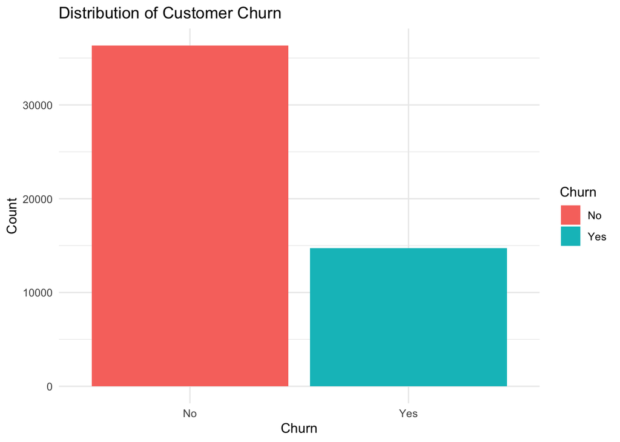

```r
#Distribution of the churn
ggplot(cell2cell, aes(x = Churn, fill = Churn)) +
  geom_bar() +
  labs(title = "Distribution of Customer Churn", x = "Churn", y = "Count") +
  theme_minimal()
```

```r
# Check the proportion of churn cases
table(cell2cell$Churn) %>% prop.table()
```

```
##
##        No       Yes
## 0.7118146 0.2881854
```

The data is imbalanced: - No (Non-Churn): 71.2% - Yes (Churn): 28.8%

To handle the missing values lets first check from which class the missing values are from:

```r
# Check if missing values are mainly from the majority class (non-churned)
cell2cell %>%
  filter(if_any(everything(), is.na)) %>%
  group_by(Churn) %>%
  summarize(count = n())
```

```
## # A tibble: 2 × 2
##   Churn count
##   <fct> <int>
## 1 No      817
## 2 Yes     454
```

- Since the missing values come from the majority (non-churned) class, it is reasonable to drop these rows. Dropping these rows will have a minimal impact on class representation.

```r
# Drop rows with any missing values
cell2cell <- cell2cell %>% drop_na()

# new dimensions
dim(cell2cell)
```

```
## [1] 49776    58
```

```r
# check na
sum(is.na(cell2cell))
```

```
## [1] 0
```

- Let’s visualize the distribution and spot any outliers or unusual values.
- Let’s start with variables that are imporatnt to my analysis, like (MonthlyRevenue, MonthlyMinutes, and perhaps AgeHH1/AgeHH2 for customer demographics).

*Monthly Revenue Distribution by Churn*

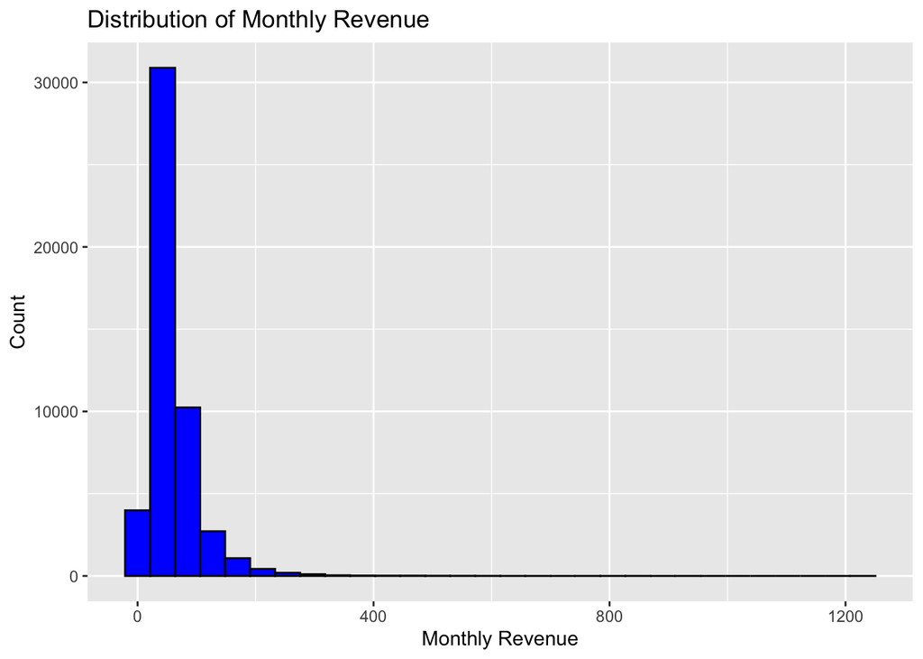

```r
ggplot(cell2cell, aes(x = MonthlyRevenue)) + geom_histogram(bins = 30, fill = "blue", color = "black") + labs(title = "Distribution of Monthly Revenue", x = "Monthly Revenue", y = "Count")
```

- The distribution of Monthly Revenue is highly right-skewed with most customers in the lower revenue brackets.

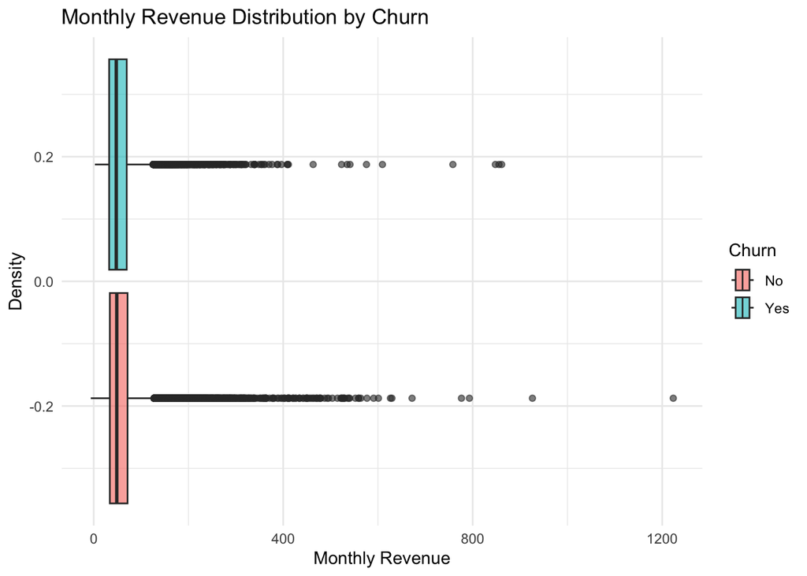

```r
ggplot(cell2cell, aes(x = MonthlyRevenue, fill = Churn)) +
  geom_boxplot(alpha = 0.6) +
  labs(title = "Monthly Revenue Distribution by Churn", x = "Monthly Revenue", y = "Density") +
  theme_minimal()
```

- There are a significant number of outliers as seen in the boxplot, with some revenue values extending well beyond the interquartile range (IQR)

- This indicates that most customers generate low to moderate revenue, while a few generate exceptionally high revenue.

Now lets check call minutes since it is a key indicator of service usage:

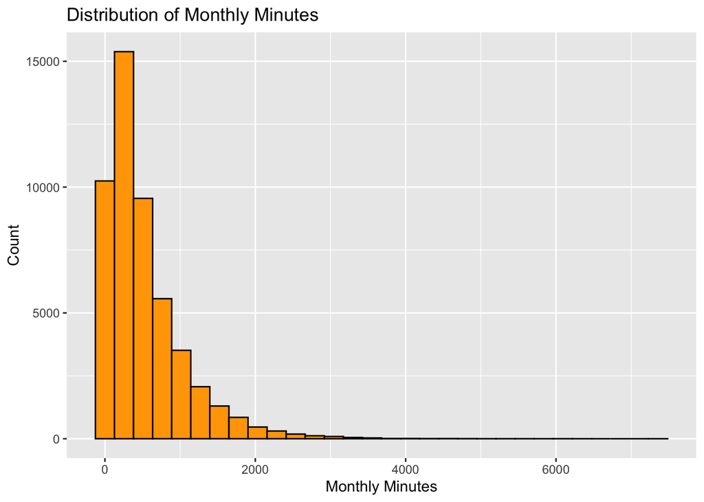

```r
#Histogram for MonthlyMinutes
ggplot(cell2cell, aes(x = MonthlyMinutes)) + geom_histogram(bins = 30, fill = "orange", color = "black") + labs(title = "Distribution of Monthly Minutes", x = "Monthly Minutes", y = "Count")
```

- Similar to revenue, the distribution is also right-skewed, indicating that most customers have low to moderate usage, while a few have very high usage.

Lets check the box plot for outliers:

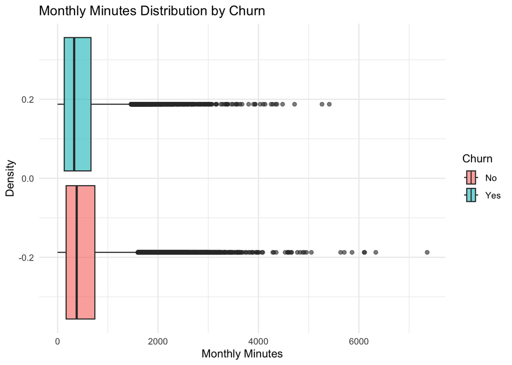

```r
ggplot(cell2cell, aes(x = MonthlyMinutes, fill = Churn)) +
  geom_boxplot(alpha = 0.6) +
  labs(title = "Monthly Minutes Distribution by Churn", x = "Monthly Minutes", y = "Density") +
  theme_minimal()
```

- The boxplot shows a high number of outliers, which might indicate irregular usage patterns among a small group of customers.

*Distribution of Household Age (AgeHH1 and AgeHH2)*

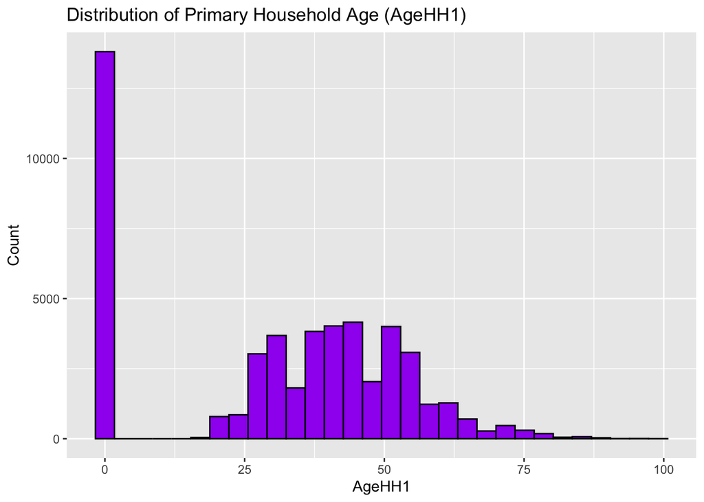

```r
ggplot(cell2cell, aes(x = AgeHH1)) + geom_histogram(bins = 30, fill = "purple", color = "black") + labs(title = "Distribution of Primary Household Age (AgeHH1)", x = "AgeHH1", y = "Count")
```

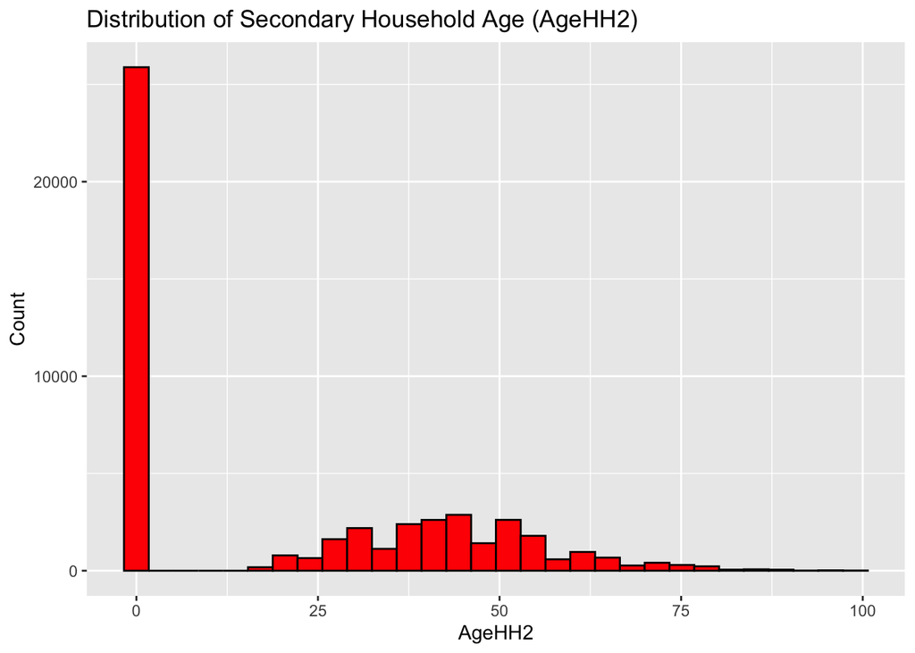

```r
ggplot(cell2cell, aes(x = AgeHH2)) + geom_histogram(bins = 30, fill = "red", color = "black") + labs(title = "Distribution of Secondary Household Age (AgeHH2)", x = "AgeHH2", y = "Count")
```

We need to investigate why why zeros exist and whether they are valid or missing data.

```r
# Check proportion of zeros in AgeHH1 and AgeHH2
cell2cell %>%
  summarise(
    AgeHH1_Zeros = sum(AgeHH1 == 0, na.rm = TRUE) / n(),
    AgeHH2_Zeros = sum(AgeHH2 == 0, na.rm = TRUE) / n()
  )
```

```
##   AgeHH1_Zeros AgeHH2_Zeros
## 1    0.2774229    0.5200297
```

- AgeHH1 Zeros: A primary household member aged 0 is biologically impossible. These are likely data entry errors or placeholders for missing values.
- AgeHH2 Zeros: Valid if they represent households with no secondary member (e.g., single-person households).

*Service Quality: Dropped Calls vs Churn*

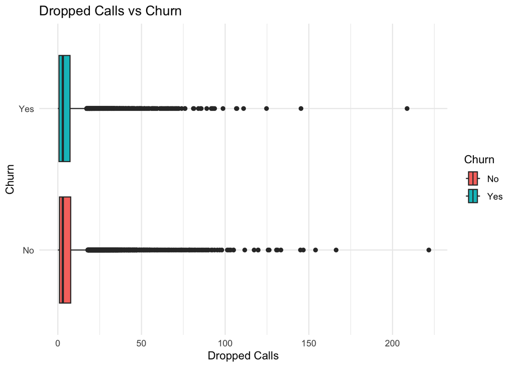

```r
ggplot(cell2cell, aes(x = DroppedCalls, y = Churn, fill = Churn)) +
  geom_boxplot() +
  labs(title = "Dropped Calls vs Churn", x = "Dropped Calls", y = "Churn") +
  theme_minimal()
```

*MonthsInService vs Churn Rate* Let’s see if newer or long-term customers churn more:

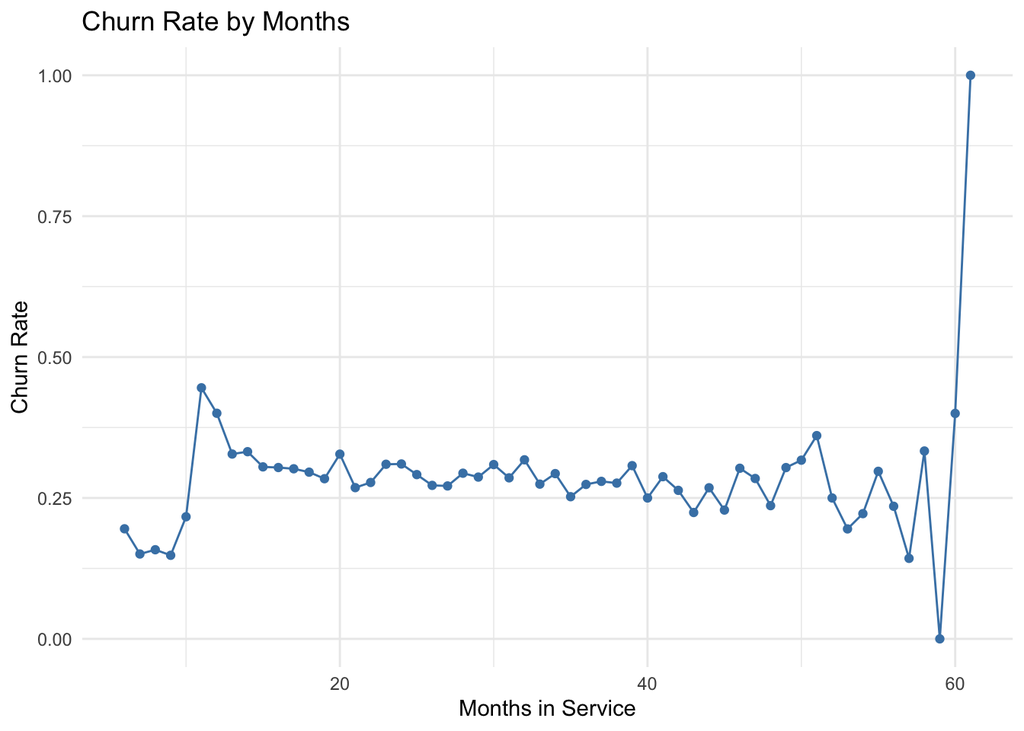

```r
cell2cell %>%
  group_by(MonthsInService) %>%
  summarise(ChurnRate = mean(Churn == "Yes")) %>%
  ggplot(aes(x = MonthsInService, y = ChurnRate)) +
  geom_line(color = "steelblue") +
  geom_point(color = "steelblue") +
  labs(title = "Churn Rate by Months", x = "Months in Service", y = "Churn Rate") +
  theme_minimal()
```

*Customer Care Calls Impact* - High call volume often predicts churn:

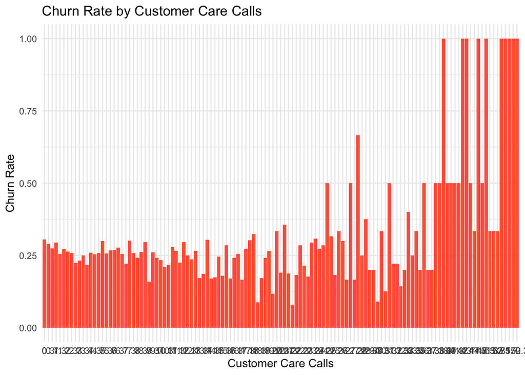

```r
cell2cell %>%
  count(CustomerCareCalls, Churn) %>%
  group_by(CustomerCareCalls) %>%
  mutate(Proportion = n / sum(n)) %>%
  filter(Churn == "Yes") %>%
  ggplot(aes(x = factor(CustomerCareCalls), y = Proportion)) +
  geom_col(fill = "tomato") +
  labs(title = "Churn Rate by Customer Care Calls", x = "Customer Care Calls", y = "Churn Rate") +
  theme_minimal()
```

*Income Group vs Churn* Check if lower-income customers churn more

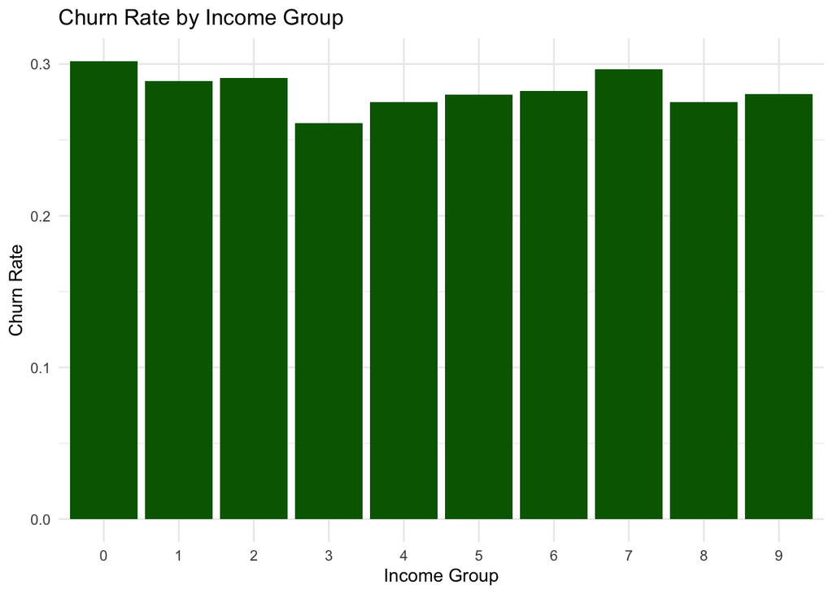

```r
cell2cell %>%
  group_by(IncomeGroup) %>%
  summarise(ChurnRate = mean(Churn == "Yes", na.rm = TRUE)) %>%
  ggplot(aes(x = factor(IncomeGroup), y = ChurnRate)) +
  geom_col(fill = "darkgreen") +
  labs(title = "Churn Rate by Income Group", x = "Income Group", y = "Churn Rate") +
  theme_minimal()
```